# BDBV 2026 outbreak: phylogenetic dating analysis

Vinicius Franceschi and Erik Volz

2026-07-15

# Summary

This report analyses genomic data generated by other researchers and originally described in the [Virological.org post](https://virological.org/t/genomic-epidemiology-of-the-ongoing-2026-bundibugyo-virus-disease-outbreak-in-the-democratic-republic-of-the-congo/1045). There is no intention to publish these analyses. Instead, this report provides complementary analyses to help understand the ongoing Bundibugyo ebolavirus (BDBV) outbreak.

## Data download and curation

The sequence alignment and associated metadata were downloaded from Pathoplexus on **9 July 2026**. The original post describes **139** sequences sampled between **2 May 2026** and **23 June 2026**; however, **149** sequences were available on Pathoplexus at the time of download.

Before analysis, we performed several curation steps, largely following the recommendations in the original post:

1. Removed sequence **PP_00764QW** because of evidence of ADAR editing.
2. Trimmed the alignment to **18,900 nt** to remove sequencing artefacts at the 3’ end (introduced by sequence **PP_006XHL9.3**, which was retained).
3. Masked the first **65 nt** and last **432 nt**, as these positions were covered in only a small number of sequences.

To make the analyses as comparable as possible with the original report, we downloaded the corresponding [Pathoplexus SeqSet](https://pathoplexus.org/seqsets/PP_SS_2740.1) and matched sequence identifiers. This yielded **127** matching sequences, indicating that the datasets are unfortunately not identical. In addition, sequence **PP_00711T3** failed the IQ-TREE composition test and was removed prior to downstream analyses.

## Alignment and tree reconstruction

Following curation, the Pathoplexus alignment was aligned to the **NC_014373** 2007 BDBV reference genome using MAFFT with the `--keeplength` and `--add` options. A maximum-likelihood (ML) phylogeny was then reconstructed using IQ-TREE 2 with ModelFinder, which selected the **K3Pu+F** substitution model (`-m MFP -B 1000 --bnni -alrt 1000`).

Quality-control checks using [Raccoon](https://github.com/artic-network/raccoon) (`aln-qc` and `tree-qc`) did not identify any issues requiring further action.

All subsequent analyses were based on this ML tree and included:

- data loading and tree rooting;
- molecular clock dating using multiple models in **treedater** and **BactDating**;
- identification and removal of temporal outliers using **treedater** and **DiagnoDating**;
- molecular clock model comparison and selection;
- root-to-tip regression;
- estimation of uncertainty in evolutionary rates and node dates;
- estimation of effective population size through time; and
- reconstruction of geographic transitions using maximum parsimony.

## 1. Load libraries

```r
library(here)
library(ape)
library(phytools)
library(glue)
library(dplyr)
library(treedater) # devtools::install_github(...)
library(lubridate)
library(ggtree) # from Bioconductor
library(ggplot2)
library(DiagnoDating, quietly = TRUE)
```

## 2. Load tree & metadata

### 2.1 Tree & alignment settings

```r
set.seed(9876)

TR_DIR <- "results/2026_07_09_5pm"
tr <- read.tree(glue("{TR_DIR}/bdbv.treefile"))
tr
```

```
##
## Phylogenetic tree with 127 tips and 125 internal nodes.
##
## Tip labels:
##   NC_014373, PP_006XHKB.2, PP_00764EH.1, PP_00765UM.1, PP_0076617.1, PP_00765M1.1, ...
## Node labels:
##   , 0/72, 75/73, 0/21, 0/4, 0/7, ...
##
## Unrooted; includes branch length(s).
```

```r
# Alignment length after masking:
aln_len <- 18900 - 65 - 432
```

### 2.2 Metadata

```r
DATA_DIR <- "data/2026_07_09_5pm/"
F_NAME <- "ebola-bdbv_metadata_2026-07-09T1550.tsv"

md <- read.csv(glue("{DATA_DIR}/{F_NAME}"), sep = "\t")

#colnames(md)
table(md$geoLocAdmin2)
```

```
##
##                       ARU         Arua        BAMBU        Bunia        BUNIA  Bunya Congo          DRC         Gety        Hoima
##            1            1            3            2           14           36            2            2            2            1
##      Kampala        Katwa         KILO      Komanda         LITA      MAMBASA      MANGALA    Mongbwalu    MONGBWALU     MONGWALU
##            5            1            2            1            4            1            1            2            1            2
##     MUNGWALU         NIZI Not provided      Ntoroko     NYAKUNDE    Nyankunde    NYANKUNDE        RIMBA     Rwampara     RWAMPARA
##            4            9            2            1            2            2            1            1           11           27
##         SOTA      unknown       Wakiso
##            1            1            3
```

### 2.3 Match metadata to tree tips

```r
length(intersect(tr$tip.label, md$accessionVersion))
```

```
## [1] 126
```

```r
md_match <- md %>%
  filter(accessionVersion %in% tr$tip.label) %>%
  dplyr::slice(match(tr$tip.label, accessionVersion))

md_match$sampleCollectionDate <- as.Date(md_match$sampleCollectionDate)
md_match$num_date <- decimal_date(md_match$sampleCollectionDate)

# Named vector of sample times
sts <- md_match$num_date
names(sts) <- md_match$accessionVersion
```

## 3. Root tree & drop outgroup

```r
.rootanddrop <- function(tr0) {
  tr_rooted <- root(tr0, outgroup = "NC_014373", resolve.root = TRUE)
  drop.tip(tr_rooted, tip = "NC_014373")
}

tr <- .rootanddrop(tr)
```

### 3.1 Root & subsample bootstrap trees

```r
nboot <- 200
btres <- read.tree(glue("{TR_DIR}/bdbv.ufboot"))
btres <- btres[sample.int(length(btres), size = nboot, replace = FALSE)]
btres <- lapply(btres, .rootanddrop)
```

## 4. Initial clock dating (strict)

```r
td0 <- dater(
  tr, sts, s = aln_len,
  clock = "strict",
  meanRateLimits = c(0.0005, 0.002),
  numStartConditions = 20, quiet = FALSE,
  ncpu = 4
)
```

[output not shown]

[output cut: 144 more lines]

```
##   iteration median_unadjusted_rate coef_of_var    tmrca   logLik
## 0         0            0.001300926           0 2026.309 -263.761
## ---
##   iteration median_unadjusted_rate coef_of_var    tmrca    logLik
## 1         1            0.001321338           0 2026.313 -265.1138
## ---
##   iteration median_unadjusted_rate coef_of_var   tmrca    logLik
## 0         0            0.001427051           0 2026.32 -268.9745
## ---
##   iteration median_unadjusted_rate coef_of_var   tmrca    logLik
## 1         1            0.001427051           0 2026.32 -268.9066
## ---
##   iteration median_unadjusted_rate coef_of_var   tmrca    logLik
## 2         2            0.001427051           0 2026.32 -268.9066
## ---
```

## 5. Outlier Removal

```r
.otips <- function(td) {
  ot <- outlierTips(td)
  ot[ot$q < 0.05, "taxon"]
}

ot <- .otips(td0)
```

```
## [1] taxon         q             p             loglik        rates         branch.length
## <0 rows> (or 0-length row.names)
```

```r
td1 <- td0
tr1 <- tr

while (length(ot) > 0) {
  tr1 <- drop.tip(tr1, ot)
  td1 <- dater(
    tr1, sts, s = aln_len,
    clock = "strict",
    meanRateLimits = c(0.0005, 0.002),
    numStartConditions = 20, quiet = TRUE, #FALSE
    ncpu = 4
  )
  ot <- .otips(td1)
}

# Tips removed as outliers (empty = none removed)
print(setdiff(td0$tip.label, td1$tip.label))
```

```
## character(0)
```

## 6. Clock model selection

### 6.1 Relaxed clock test

```r
rct <- relaxedClockTest(
  tr1, sts, aln_len,
  meanRateLimits = c(0.0005, 0.002),
  quiet = FALSE, ncpu = 8, nreps=100,
  overrideTempConstraint = FALSE
)
```

```
## Note: Initial guess of substitution rate not provided. Will attempt to guess starting conditions. Provide initial guesses of the rate using *omega0* parameter.
## Note: Minimum temporal branch length  (*minblen*) set to 0.000113068058273516. Increase *minblen* in the event of convergence failures.
## Tree is rooted. Not estimating root position.
## Initial guesses of substitution rate: 0.000243214384353623,0.000429820841437541,0.00122945913758186,0.0014301443779574
##   iteration median_unadjusted_rate coef_of_var    tmrca   logLik
## 0         0            0.001300926           0 2026.309 -263.761
## ---
##   iteration median_unadjusted_rate coef_of_var    tmrca    logLik
## 1         1            0.001321338           0 2026.313 -265.1138
## ---
##   iteration median_unadjusted_rate coef_of_var   tmrca    logLik
## 0         0            0.001427051           0 2026.32 -268.9745
## ---
##   iteration median_unadjusted_rate coef_of_var   tmrca    logLik
## 1         1            0.001427051           0 2026.32 -268.9066
## ---
##   iteration median_unadjusted_rate coef_of_var   tmrca    logLik
## 2         2            0.001427051           0 2026.32 -268.9066
## ---
## Running in quiet mode. To print progress, set quiet=FALSE.
## NOTE: Running with overrideSearchRoot will speed up execution but may underestimate variance.
## Note: Initial guess of substitution rate not provided. Will attempt to guess starting conditions. Provide initial guesses of the rate using *omega0* parameter.
## Note: Minimum temporal branch length  (*minblen*) set to 0.000113068058273516. Increase *minblen* in the event of convergence failures.
## Tree is rooted. Not estimating root position.
## Initial guesses of substitution rate: 0.000243214384353623,0.000429820841437541,0.00122945913758186,0.0014301443779574
##   iteration median_unadjusted_rate  coef_of_var    tmrca    logLik
## 0         0            0.001283731 0.0008026324 2026.309 -263.7513
## ---
##   iteration median_unadjusted_rate  coef_of_var    tmrca    logLik
## 1         1            0.001325979 0.0008079653 2026.312 -264.6144
## ---
##   iteration median_unadjusted_rate coef_of_var   tmrca   logLik
## 0         0            0.001411919  0.02170761 2026.32 -268.942
## ---
##   iteration median_unadjusted_rate coef_of_var    tmrca    logLik
## 1         1            0.001388365 0.006547859 2026.317 -264.7113
## ---
##   iteration median_unadjusted_rate coef_of_var    tmrca    logLik
## 2         2            0.001390134 0.007328805 2026.317 -266.2935
## ---
## Best clock model:  strict
## Null distribution of rate coefficient of variation: 0.000594412952690844 0.0174801414292417
## Returning best treedater fit
```

### 6.2 Fit uncorrelated & additive relaxed clocks

```r
# Uncorrelated
td1u <- dater(
  tr1, sts, s = aln_len,
  clock = "uncorrelated",
  meanRateLimits = c(0.0005, 0.002),
  numStartConditions = 20, quiet = FALSE,
  ncpu = 4
)
```

[output not shown]

[output cut: 144 more lines]

```
##   iteration median_unadjusted_rate  coef_of_var    tmrca    logLik
## 0         0            0.001283731 0.0008026324 2026.309 -263.7513
## ---
##   iteration median_unadjusted_rate  coef_of_var    tmrca    logLik
## 1         1            0.001325979 0.0008079653 2026.312 -264.6144
## ---
##   iteration median_unadjusted_rate coef_of_var   tmrca   logLik
## 0         0            0.001411919  0.02170761 2026.32 -268.942
## ---
##   iteration median_unadjusted_rate coef_of_var    tmrca    logLik
## 1         1            0.001388365 0.006547859 2026.317 -264.7113
## ---
##   iteration median_unadjusted_rate coef_of_var    tmrca    logLik
## 2         2            0.001390134 0.007328805 2026.317 -266.2935
## ---
```

```r
# Additive
td1a <- dater(
  tr1, sts, s  = aln_len,
  clock = "additive",
  meanRateLimits = c(0.0005, 0.002),
  numStartConditions = 20, quiet = FALSE,
  ncpu = 4
)
```

[output not shown]

[output cut: 278 more lines]

[output not shown]

```r
# Compare log-likelihoods: uncorrelated vs additive
c(td1u$loglik, td1a$loglik)
```

```
## [1] -249.7674 -215.9803
```

### 6.3 Inspect best-fit model (strict)

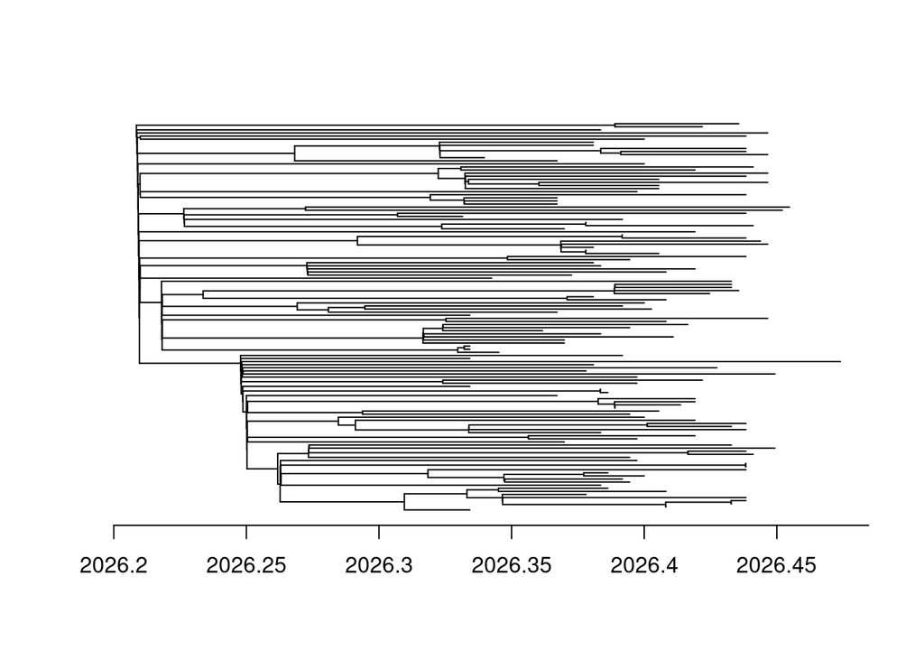

```r
# Time tree plot
plot(td1, show.tip.label = F)
axisPhylo(root.time = td1$timeOf, backward = FALSE)
```

```r
# Summary
td1
```

```
##
## Phylogenetic tree with 126 tips and 125 internal nodes.
##
## Tip labels:
##   PP_006XHKB.2, PP_00764EH.1, PP_00765UM.1, PP_0076617.1, PP_00765M1.1, PP_0076SYS.1, ...
## Node labels:
##   , 0/72, 75/73, 0/21, 0/4, 0/7, ...
##
## Rooted; includes branch length(s).
##
##  Time of common ancestor
## 2026.20852968182
##
##  Time to common ancestor (before most recent sample)
## 0.265442920918304
##
##  Weighted mean substitution rate (adjusted by branch lengths)
## 0.000633988705841585
##
##  Unadjusted mean substitution rate
## 0.000633988705841585
##
##  Clock model
## strict
##
##  Coefficient of variation of rates
## 0
```

```r
# MRCA date
date_decimal(td1$timeOfMRCA)
```

```
## [1] "2026-03-18 02:43:12 UTC"
```

### 6.4 Root-to-tip regression

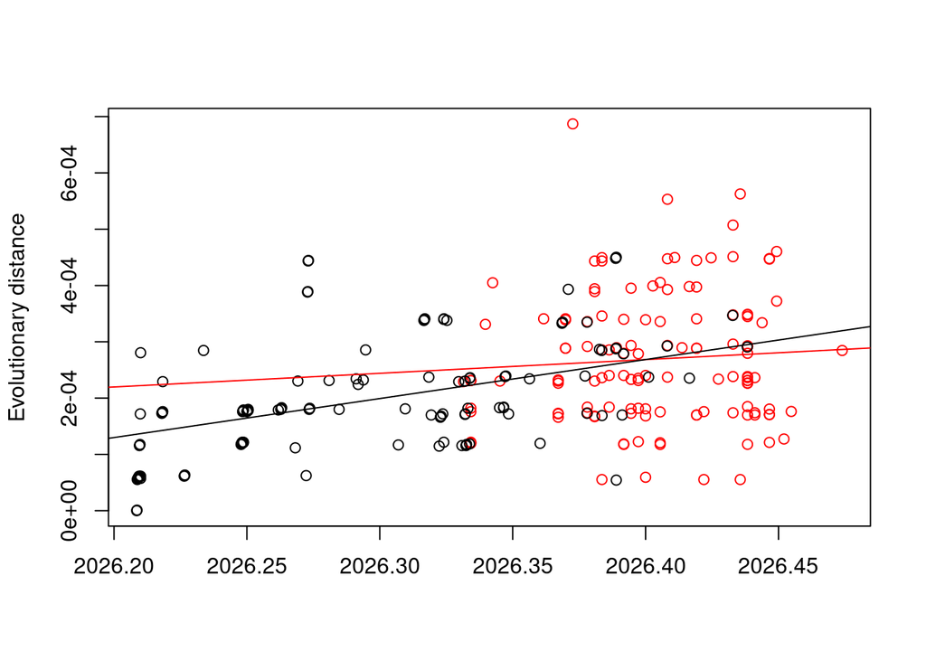

```
## Root-to-tip mean rate: 0.000243214384353623
## Root-to-tip p value: 0.447464470486757
## Root-to-tip R squared (variance explained): 0.0046616579901538
## Returning fitted linear model.
```

```r
rootToTipRegressionPlot(td1)
```

## 7. Bootstrap for confidence intervals (from iqtree ufboot distribution)

```r
# Bootstrap
btd <- treedater::boot(
  td1, btres,
  ncpu = 8,
  overrideTempConstraint = FALSE, quiet = TRUE
)
```

```
## Running in quiet mode. To print progress, set quiet=FALSE.
```

```r
btd
```

```
##                            pseudo ML        2.5 %       97.5 %
## Time of common ancestor 2.026209e+03 2.026089e+03 2.026291e+03
## Mean substitution rate  6.339887e-04 3.357899e-04 1.343159e-03
##
##  For more detailed output, $trees provides a list of each fit to each simulation
```

```r
# Bootstrap CI on MRCA date
date_decimal(btd$timeOf)
```

```
##                      2.5%                     97.5%
## "2026-02-02 13:02:11 UTC" "2026-04-17 01:34:46 UTC"
```

## 8. BactDating

```r
trbd1 <- tr1
trbd1$edge.length <- trbd1$edge.length * aln_len

bd1a <- bactdate(
  trbd1, sts[tr1$tip.label],
  initMu = aln_len * td1$mean.rate,
  model = "arc", showProgress = FALSE # TRUE
)

bd1a
```

```
## Phylogenetic tree dated using BactDating
##
## Phylogenetic tree with 126 tips and 125 internal nodes.
##
## Tip labels:
##   PP_006XHKB.2, PP_00764EH.1, PP_00765UM.1, PP_0076617.1, PP_00765M1.1, PP_0076SYS.1, ...
## Node labels:
##   , 0/72, 75/73, 0/21, 0/4, 0/7, ...
##
## Rooted; includes branch length(s).
## Probability of root branch=0.49
## likelihood=-2.62e+02 [-2.75e+02;-2.49e+02]
## prior=-2.28e+02 [-2.59e+02;-2.00e+02]
## mu=1.29e+01 [9.45e+00;1.67e+01]
## sigma=3.09e-01 [1.66e-02;6.20e-01]
## alpha=2.31e+00 [1.72e+00;3.10e+00]
## Root date=2025.86 [2025.63;2026.06]
## Root date for most likely root=2025.86 [2025.64;2026.05]
```

> **Note:** The estimated mean rate from BactDating is consistent with treedater, but the inferred root date may not be biologically plausible.

## 9. DiagnoDating

### 9.1 Root-to-tip (DiagnoDating)

NEEDS DiagnoDating >= 0.9.1, ie the fix-treedater-units branch (PR #1), which is where the additive clock, the seqlen argument and matching of named dates were fixed. Before that, treedater results always came back as model=‘poisson’ with relax=0:

```
devtools::install_github('xavierdidelot/DiagnoDating', ref = 'fix-treedater-units')
```

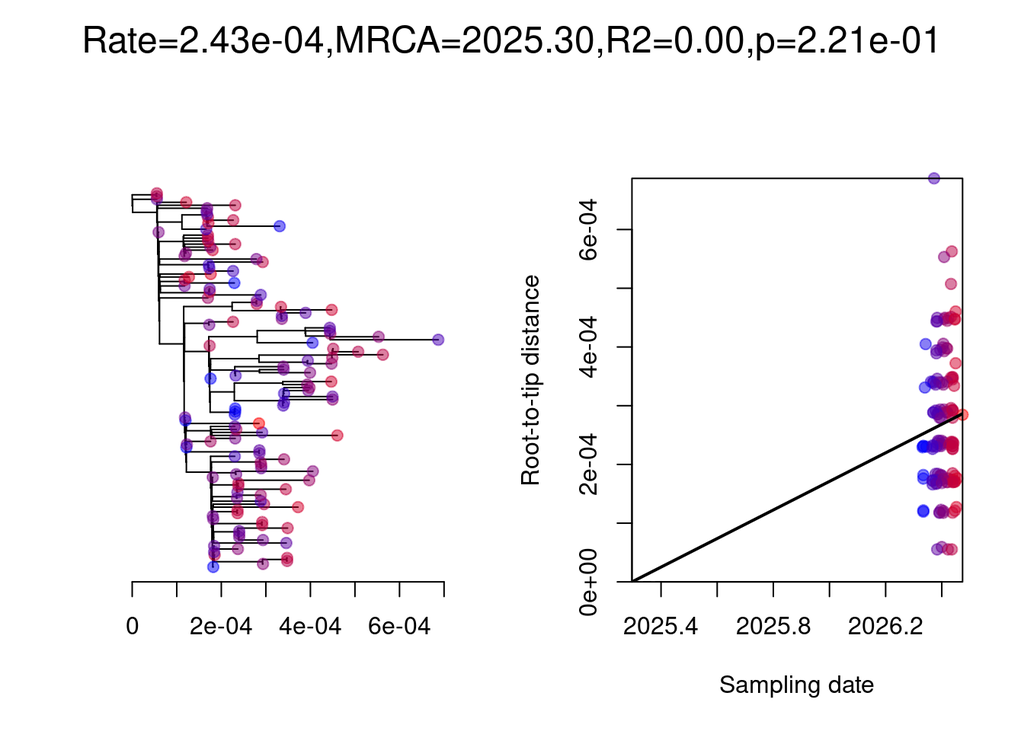

```
## $rate
##         date
## 0.0002432144
##
## $ori
## (Intercept)
##    2025.296
##
## $pvalue
## [1] 0.2215
```

```r
roottotip(tr1, sts)
```

DiagnoDating, like BactDating, wants branch lengths in substitutions rather than per site, so rescale the tree. seqlen then tells treedater how to convert back, and omega0 and meanRateLimits stay in treedater’s own units of substitutions per site per year.

```r
trdd <- tr1
trdd$edge.length <- trdd$edge.length * aln_len
```

### 9.2 Run & diagnose

```r
ddtd <- runDating( trdd, sts[ tr1$tip.label ], algo = 'treedater', keepRoot = TRUE,
                   seqlen = aln_len, clock = 'strict', omega0 = td1$mean.rate, meanRateLimits = td1$mean.rate*c(1,1+1e-6) ) #additive
```

```r
ddtd
```

```
## Result from treedater, model poisson, clock rate 11.67, relaxation parameter 0.00, root date 2026.23
```

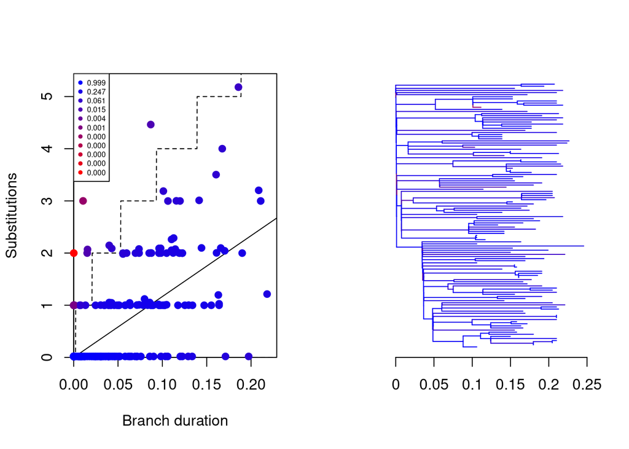

```r
plotLikBranches(ddtd)
```

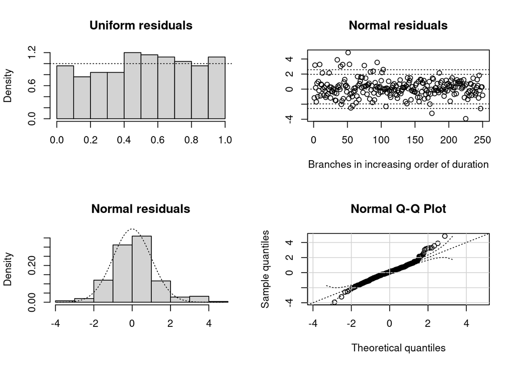

```r
plotResid(ddtd)
```

```r
# Anderson-Darling normality test on residuals
testResid(ddtd)
```

```
##
##  Anderson-Darling test of goodness-of-fit
##  Null hypothesis: Normal distribution
##  with parameters mean = 0.000, sd = 1.000
##
## data:  n
## An = 2.4185, p-value = 0.05473
```

## 10. Profile likelihood for the clock rate

```r
ratetologlik <- function(omega){
    print( omega )
    td <- dater(tr1, sts, s=aln_len,  clock="additive", omega0 = omega, meanRateLimits = omega*c(.9,1.4), quiet=TRUE, ncpu=4)
    c( td$adjusted.mean.rate, td$loglik )
}

omegas <- seq( 0.0001, 0.002, length.out = 30)
llprof <- sapply( omegas, ratetologlik )
omegas <- llprof[1,]
llprof <- llprof[2,]
source( 'scripts/profplot-02b.R')
```

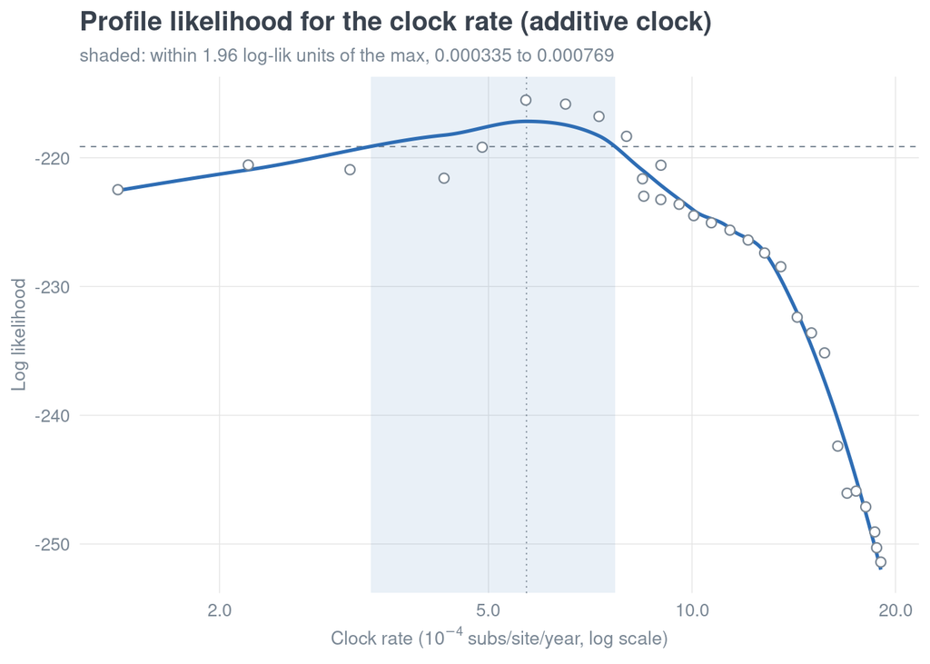

```r
prpl <- profplot( omegas, llprof )
prpl
```

## 11. Effective population size (mlesky)

```r
library(mlesky)
range_tr <- max(sts) - td1$timeOfMRCA
range_tr_weeks <- ceiling(range_tr * 52.1775)
range_tr_weeks
```

```
## [1] 14
```

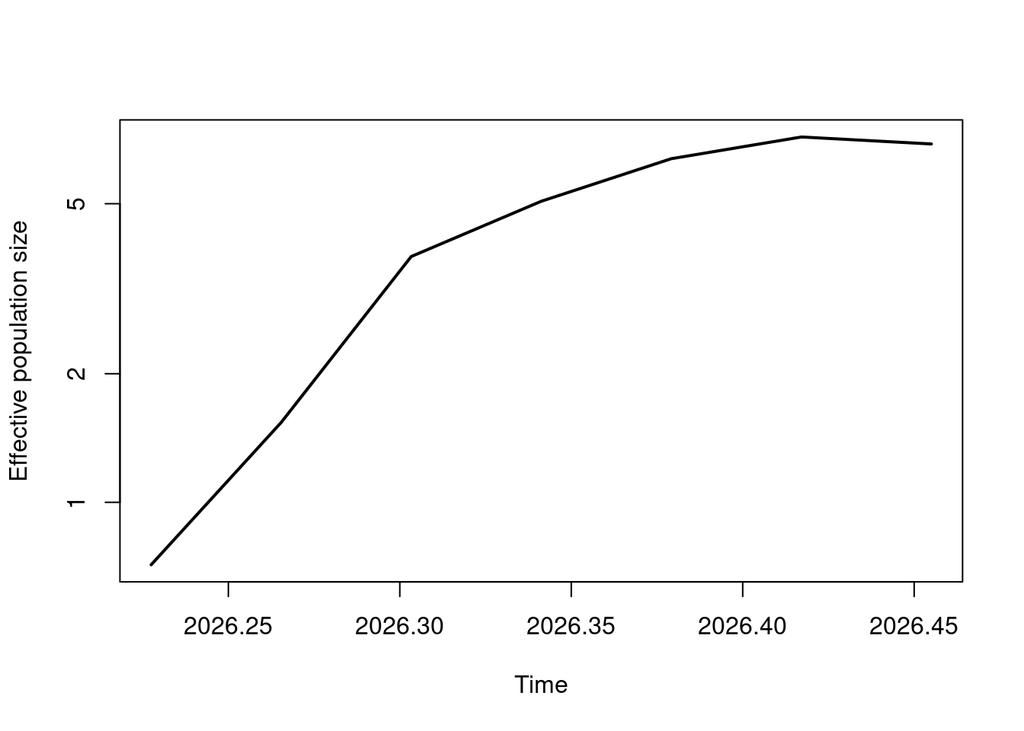

```r
mlsk <- mlskygrid(td1, sampleTimes=sts, res=NULL, tau=NULL, tau_lower=0.001, tau_upper=100,
                  ncross=10, ncpu=4, quiet=F, model=2)
plot(mlsk, logy=T)
```

```r
mlsk$res
mlsk$tau
```

[output not shown]

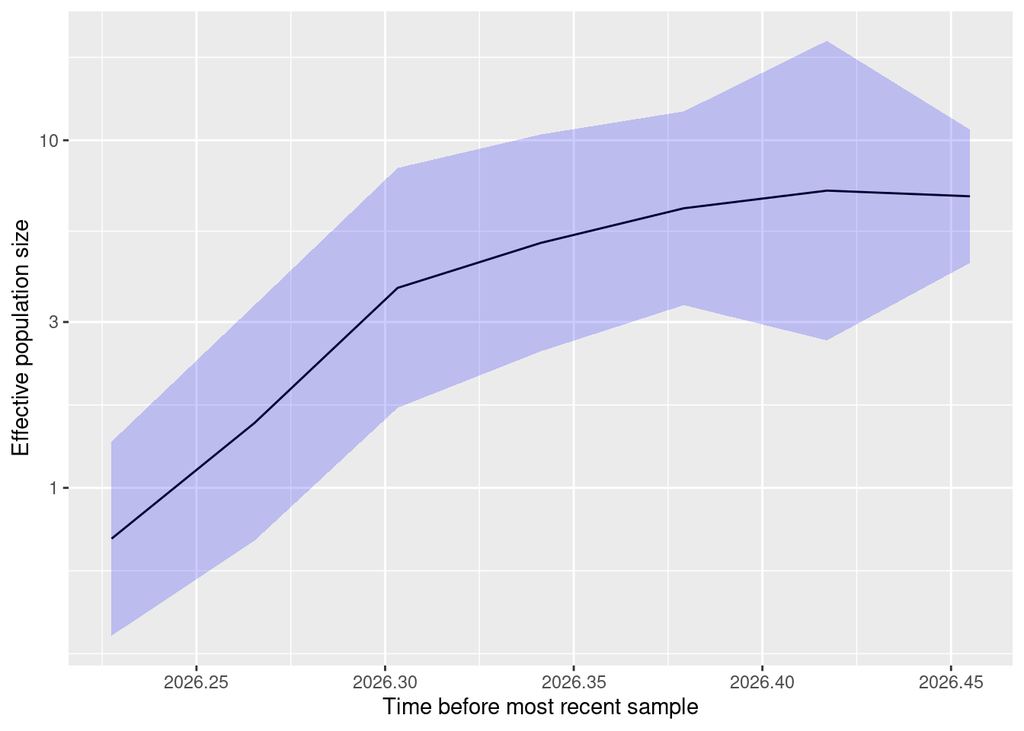

```r
mlsk_pboot <- mlesky::parboot(mlsk, nrep=1000, ncpu=8, dd=F)
# regular bootstrap NEEDS mlesky >= 0.1.9: # devtools::install_github('emvolz-phylodynamics/mlesky')
# bmlsk <- mlesky::boot( mlsk, btd$trees, ncpu = 8, sampleTimes = sts )
plot(mlsk_pboot, logy=T, ggplot=T)
```

## 12. Ancestral state estimation with tree figure

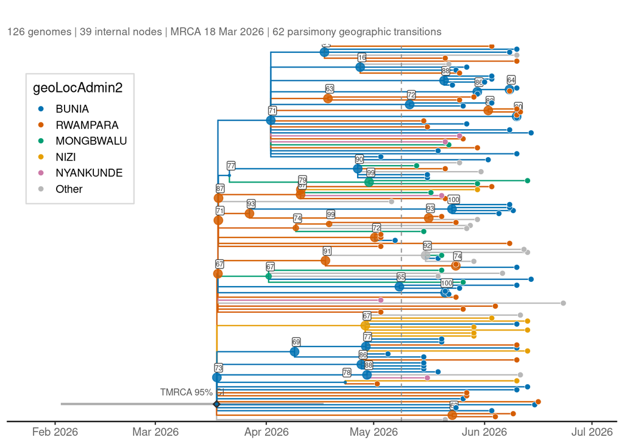

```r
library(phangorn)

collapse_dated <- function(td, aln_len, min_subs = 0.5) {
    phy  <- as.phylo(td)
    subs <- td$intree$edge.length * aln_len              # substitutions per edge (aligned to phy$edge)
    nd   <- node.depth.edgelength(phy)                   # node heights (time) from root
    tmp  <- phy; tmp$edge.length <- subs
    topo <- di2multi(tmp, tol = min_subs)                # collapse by substitutions
    Ntt  <- Ntip(topo); dts <- numeric(Ntt + topo$Nnode) # re-time from the original treedater dates
    dts[1:Ntt] <- (td$timeOfMRCA + nd[1:Ntip(phy)])[match(topo$tip.label, phy$tip.label)]
    desc <- Descendants(topo, (Ntt+1):(Ntt+topo$Nnode), "tips")
    for (i in seq_along(desc)) {
        tips <- topo$tip.label[desc[[i]]]
        mn   <- if (length(tips)==Ntip(phy)) Ntip(phy)+1 else getMRCA(phy, tips)
        dts[Ntt+i] <- td$timeOfMRCA + nd[mn]
    }
    topo$edge.length <- dts[topo$edge[,2]] - dts[topo$edge[,1]]
    topo$root.time   <- td$timeOfMRCA
    topo
}
.norm <- function(x){ x <- toupper(trimws(x)); x[x=="" | x=="NOT PROVIDED"] <- "UNKNOWN"
    dplyr::recode(x, "MONGWALU"="MONGBWALU","MUNGWALU"="MONGBWALU","NYAKUNDE"="NYANKUNDE") }
# shared locality set + palette (both trees have identical tips, so colours are comparable)
loc0 <- .norm(md_match$geoLocAdmin2[ match(as.phylo(td1)$tip.label, md_match$accessionVersion) ])
top5 <- names(sort(table(loc0), decreasing=TRUE))[1:5]
LEV  <- c(top5, "Other")
pal  <- setNames(c("#0072B2","#D55E00","#009E73","#E69F00","#CC79A7","grey72"), LEV)
mrsd <- as.Date(date_decimal(max(sts))); ci <- btd$timeOfMRCA_CI; break_gr <- 2026.35
mb <- decimal_date(seq(as.Date("2026-01-01"), as.Date("2026-08-01"), by="month"))
ml <- format(seq(as.Date("2026-01-01"), as.Date("2026-08-01"), by="month"), "%b %Y")

geo_tree_fig <- function(tree, root_date, title) {
    phy <- as.phylo(tree); nt <- Ntip(phy)
    loc <- .norm(md_match$geoLocAdmin2[ match(phy$tip.label, md_match$accessionVersion) ])
    loc[!loc %in% top5] <- "Other"
    dat <- phangorn::phyDat(as.matrix(data.frame(s=loc, row.names=phy$tip.label)), type="USER", levels=LEV)
    mat <- do.call(rbind, lapply(phangorn::ancestral.pars(phy, dat, "MPR"), function(z) z[1,])); colnames(mat) <- LEV
    map  <- LEV[apply(mat,1,which.max)]; conf <- apply(mat,1,max)
    ntrans <- sum(map[phy$edge[,1]] != map[phy$edge[,2]])
    lab <- rep(NA_character_, nt+phy$Nnode)               # UFBoot labels, only on collapsed trees
    if (!is.binary(phy)) {
        ufb <- as.numeric(sub(".*/", "", tr1$node.label))
        for (n in (nt+1):(nt+phy$Nnode)) {
            tips <- phy$tip.label[ unlist(phangorn::Descendants(phy, n, "tips")) ]
            mn <- if (length(tips)==nt) Ntip(tr1)+1 else getMRCA(tr1, tips)
            if (!is.null(mn) && !is.na(mn)) lab[n] <- as.character(round(ufb[mn - Ntip(tr1)]))
        }
    }
    nodedf <- data.frame(node=1:(nt+phy$Nnode), state=factor(map,levels=LEV), conf=conf, lab=lab)
    pg <- ggtree(tree, mrsd=mrsd, size=0.5) %<+% nodedf + aes(color=state)
    # ggtree rounds mrsd to whole days, shifting its x-axis; off re-aligns absolute-date annotations
    rootx <- pg$data$x[pg$data$node == nt+1]; rooty <- pg$data$y[pg$data$node == nt+1]
    off <- rootx - root_date; cih <- 0.4   # half-height of the thin TMRCA CI band, in tip-row units
    pg$layers <- c(annotate("rect", xmin=ci[1]+off, xmax=ci[2]+off, ymin=rooty-cih, ymax=rooty+cih, fill="grey30", alpha=0.45), pg$layers)  # thin TMRCA 95% CI band at the root, behind the tree
    pg +
        geom_vline(xintercept=break_gr+off, linetype="dashed", color="grey55", linewidth=0.4) +
        # annotate("label", x=break_gr+off, y=nt*0.965, label="growth-rate\nchange 2026.35", size=2.7,
        #          color="grey40", hjust=-0.04, vjust=1, lineheight=0.9, fill="white", alpha=0.7) +
        annotate("point", x=rootx, y=rooty, shape=18, size=2.8, color="grey20") +
        annotate("text", x=mean(ci)+off, y=rooty+cih+nt*0.02, label="TMRCA 95% CI", size=2.6, color="grey35", vjust=0) +
        geom_nodepoint(aes(color=state, size=conf), alpha=0.85) +
        geom_nodelab(aes(label=lab), geom="label", size=1.9, vjust=-0.6, color="grey20",
                     fill="white", label.size=0, label.padding=unit(0.04,"lines"), na.rm=TRUE) +
        geom_tippoint(aes(fill=state), shape=21, size=2, stroke=0.25, color="white") +
        scale_color_manual(values=pal, guide="none") +
        scale_fill_manual(values=pal, name="geoLocAdmin2") +
        scale_size_continuous(range=c(0.6,3), guide="none") +
        scale_x_continuous(breaks=mb+off, labels=ml, limits=c(min(ci[1]+off, rootx)-0.02, max(sts)+off+0.02)) +
        labs(title=title,
             subtitle=glue("{nt} genomes | {phy$Nnode} internal nodes | MRCA {format(as.Date(date_decimal(root_date)),'%d %b %Y')} | {ntrans} parsimony geographic transitions")) +
        theme_tree2() +
        theme(plot.title=element_text(face="bold",size=12), plot.subtitle=element_text(size=8.5,color="grey40"),
              axis.text.x=element_text(size=9,color="grey40"), legend.position=c(0.12,0.75),
              legend.background=element_rect(fill="white",color="grey85"), legend.key.size=unit(0.9,"lines"))
}

td1_collapsed <- collapse_dated(td1, aln_len, min_subs = 0.5)
pg_coll <- geo_tree_fig(td1_collapsed, td1_collapsed$root.time, "")
print(pg_coll)
```